# Curso Introductorio al uso de R Studio- Clase 1

## Contenidos

[figure not shown]

- **Instalación de software**
- Ventajas/Desventajas de R y RStudio
- Entorno de trabajo
- Objetos de trabajo
- Instalación de Paquetes estadísticos
- Tipos de Variables
- Valores Especiales
- Recursos en línea
- Importar Datos de Fuentes Externas
- Estadística Descriptiva Básica
- Configuración de datos

## Presentación

- Andrés González Santa Cruz
- Ustedes: Nombre, nivel de manejo en R, experiencias previas con este software o similares, manejo informático, ¿tuvieron problemas en instalar R?

## Instalación

- En la página pudieron ver cómo se instalaba R,

  **¿Alguna Duda?**
  - Problemas frecuentes:
  - Microsoft R vs. R, Arquitectura SO (64bits vs. 32bits),
  - Conectar al servidor de repositorios (firewall, puertas de enlace bloqueadas, permisos de administrador, etc.),
  - **y un montón de cosas que se resuelven leyendo en internet.**

## Ventajas/Desventajas de R y RStudio

**A la hora de elegir qué utilizará, debe considerar estos atributos**

### Ventajas

- Flexible
- Actualizaciones constantes
- Fácil automatización e integración
- Muchos recursos en-línea y comunidades
- Útil para ser enseñado a estudiantes
- Investigación Reproducible
- **Gratis** - Fuente Abierta

### Desventajas

- No tan intuitivo
- No tan confiable
- A ratos muy flexible
- No cuenta con soporte oficial
- Requiere tiempo

## Ventajas/Desventajas de R y RStudio

### Algunos Memes

[figure not shown]

[figure not shown]

## Ventajas/Desventajas de RStudio

### Ventajas

- **Entorno de Desarrollo Integrado para R**
- Control de versiones
- Paneles múltiples
- Permite automatizar algunas funciones de R (Knitr)
- Fácil Depurador (errores)
- Eficienta Recursos Computacionales
- Cuenta con soporte, versiones en servidor y grandes desarrolladores

### Desventajas

- Algo inestable (Ej. “Figure margins too large”)
- Tareas exigentes computacionalmente son más lentas

## Entorno de Trabajo

- Apriete `Cntrl + Alt + Shift 0`
  - Editor de texto o códigos
  - Lugar de trabajo (objetos creados, funciones, historial, control de versiones)
  - Consola para desplegar los comandos y obtener resultados
  - Multitabla(gráficos, carpetas, paquetes, visor páginas web)

[figure not shown]

## Ejercicio

1. Abra RStudio
2. Cree una sesión nueva

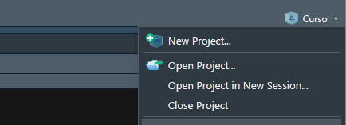

[figure not shown]

[figure not shown]

[figure not shown]

[figure not shown]

## Ejercicio (continuación)

- Cargamos la base de datos

```r
set.seed(4567);df_ej<- data.frame(numeros=round(rnorm(1:200)*100,0))
```

```r
set.seed(4567);head(data.frame(numeros=round(rnorm(1:200)*100,0)),2)
```

```
##   numeros
## 1     -74
## 2     -90
```

- Vemos los primeros 2 números y los sumamos

```r
-74-90
```

```
## [1] -164
```

- Ejecuto en la consola lo siguiente: `sessionInfo` (detalles de la sesión y configuración programa) y `dput` (para que otros puedan trabajar fácilmente sobre los datos que trabajas). Permite control y que los datos sean reproducibles (ej. Github).

```r
dput(head(data.frame(numeros=round(rnorm(1:200)*100,0)),2))
```

```
## structure(list(numeros = c(15, 234)), row.names = 1:2, class = "data.frame")
```

[session information not shown]

```r
###
```

- Guardo los objetos creados (.Rdata) y guardo la sesión (.Rproj) que los contiene

## Ejercicio: Hágalo usted

Cree un nuevo proyecto en R

Genere la siguiente base de datos recurriendo a este código: `set.seed(6789); df2<- data.frame(numeros=round(rnorm(1:300)*100,0))`

Utilizando `tail(df2)` obtenga las últimas 6 observaciones

Súmelas

¿Llegó al siguiente número: 12?

OPC1 = obtenga la media de todos los números (use recursos en línea)

OPC2 (+ avanzada)= btenga el resultado usando comas como separador de decimales (“outdec” en internet)

OPC3 = Obtenga la desviación estandar, separando los decimales con comas

Guarde los datos (.Rdata) y el proyecto (.RProj)

Reinicie el computador. Vuelva a abrirlo

## Fuente

- R vs Stata: Which one is best for Data Science: https://youtu.be/KqWAmpb4iyc
- Ozgur, C., Colliau, T., Rogers, G., Hughes, Z. & Bennie, E. (2017). MatLab vs. Python vs. R. Journal of data science: JDS. 15. 355-372.
- Ozgur, C., Kleckner, M., & Li, Y. (2015). Selection of Statistical Software for Solving Big Data Problems. SAGE Open, 5(2), 215824401558437. doi:10.1177/2158244015584379
- Boccardo, Giorgio & Ruiz, Felipe. (2018). Uso de RStudio para Estadística Univariada en Ciencias Sociales. Manual de apoyo docente para la asignatura Estadística Descriptiva (1a. Edición). 10.13140/RG.2.2.32783.48803.
- Elosua, P. (2009). ¿Existe vida más allá del SPSS? Descubre R. Psicothema, 21(4),652-655. ISSN: 0214-9915. Disponible en: https://www.redalyc.org/articulo.oa?id=727/72711895025
- Cano, E. & Moguerza, J. (2015). “R desde el principio. Curso ceRo de R”. Ediciones del Orto, Madrid. ISBN 84-7923-526-8. http://emilio.lcano.com/pub/cero/R-desde-el-principio-curso-cero-V1.02.pdf
- R Development Core Team (2000). Introducción a R. Notas sobre R: Un entorno de programación para Análisis de Datos y Gráficos. Versión 1.0.1 https://cran.r-project.org/doc/contrib/R-intro-1.1.0-espanol.1.pdf
- Lortie CJ. 2017. A review of R for Data Science: key elements and a critical analysis. PeerJ Preprints 5:e2873v1

## Prueba

Favor dirigirse al siguiente [enlace](https://forms.gle/gi7Zrw6ZB4d5q7Ta7) y contestar